# Barbell Lift Technique Analysis

Gary Laughton

## Overview

The objective of this analysis is to develop a model that will identify errors in form for dumbbell lifts using data from accelerometers on the belt, forearm, arm, and dumbell of 6 participants. The participants were asked to perform these lifts correctly and incorrectly in 5 different ways. The lift categories are as folllows:

1. A: Exactly according to specification - correct
2. B: Throwing elbows to the front
3. C: Lifting dumbbell only halfway
4. D: Lowering dumbbell only halfway
5. E: Throwing hips to the front

The model was fitted using the Weight Lifting Exercises dataset published by Velloso, Gellersen, Ugulino, and Fuks. After cleaning the data, I split the training set data into a training and validation set then tested several classification models. I chose the model that best fit the validation data. This turned out to be a Random Forest model. The model was then applied to the testing set of 20 observations to predict the error class.

## Input - Read, Clean and Partition Dataset

Read the training and testing data. Remove any columns not related to data from accelerometers on the belt, forearm, arm, and dumbell. Do not include subject identifier as we’re trying to build a model to measure lift quality for any weightlifter. Remove any column with N/As or #DIV/0 in the training set. Also remove any columns identified as skewness, kurtosis or amplitude_yaw. These are summary data across windows and are only included in a few select rows. The columns removed contain little data so they should not significantly affect model fit.

Since we have a large training split it into a training and validation set so we can estimate the out of sample error. The split is 60% training and 40% validation.

```r
# Read data
library(caret)
pml_dat<-read.csv("pml-training.csv")
pml_tst<-read.csv("pml-testing.csv")

# Filter out N/A and DIV/0 columns
cl<-!colSums(is.na(pml_dat))
cl[c(1,2,3,4,5,6,7)]=FALSE
cl<-cl & !grepl("skewness", names(pml_dat))
cl<-cl & !grepl("kurtosis", names(pml_dat))
cl<-cl & !grepl("amplitude_yaw", names(pml_dat))
cl<-cl & !grepl("max_yaw", names(pml_dat))
cl<-cl & !grepl("min_yaw", names(pml_dat))
#pml_dat<-pml_dat[sample(1:19622,1000),cl]
pml_dat<-pml_dat[,cl]
pml_tst<-pml_tst[,cl]

# Split training into a training and validation set
set.seed(3456)
inTrain <- createDataPartition(y=pml_dat$classe, p=0.6, list=FALSE)
pml_trn <- pml_dat[inTrain,]
pml_val <- pml_dat[-inTrain,]
```

## Exploratory Analysis

Examine the distribution of error classes in the training dataset. Examples of each error classe and correct technique are well represented in the data set.

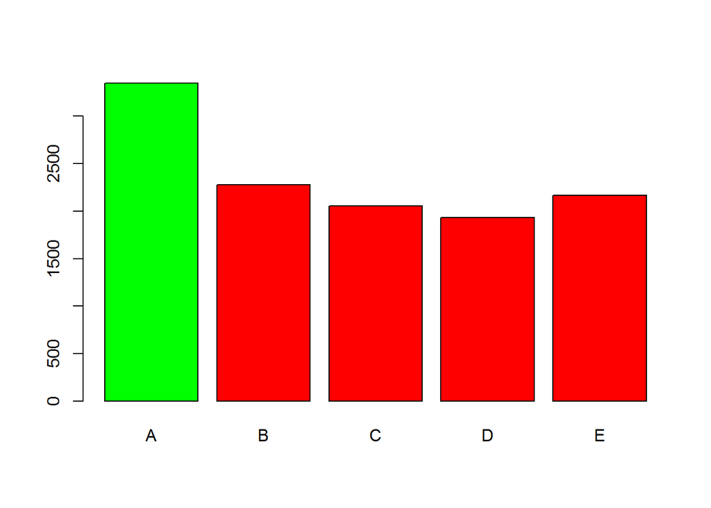

```r
cCol<-c("green", "red", "red", "red", "red")
barplot(table(pml_trn$classe), col = cCol,)
```

## Model Selection: Algorithms and Parameters

I considered the following three classifcation models: Random Forest, Boosting and Linear Discriminant Analysis, then fit each of these models to the training set with K-fold cross validation on 10 subsets. Cross validation supports measuring the variability of the model accuracy against other samples. 10 samples should provide a reasonable unbiased estimator without too much variance.

```r
library(caret)
train_control <- trainControl(method="cv", number=10)
modelFitRF  <- train(classe ~ ., method="rf", trControl=train_control, data=pml_trn, verbose = FALSE)
modelFitRF
```

```
## Random Forest
##
## 11776 samples
##    52 predictor
##     5 classes: 'A', 'B', 'C', 'D', 'E'
##
## No pre-processing
## Resampling: Cross-Validated (10 fold)
## Summary of sample sizes: 10599, 10598, 10597, 10598, 10598, 10599, ...
## Resampling results across tuning parameters:
##
##   mtry  Accuracy   Kappa      Accuracy SD  Kappa SD
##    2    0.9904038  0.9878598  0.002746972  0.003476593
##   27    0.9898937  0.9872148  0.004712168  0.005962607
##   52    0.9841200  0.9799090  0.005589986  0.007078352
##
## Accuracy was used to select the optimal model using  the largest value.
## The final value used for the model was mtry = 2.
```

```r
modelFitGBM <- train(classe ~ ., method="gbm", trControl=train_control, data=pml_trn, verbose = FALSE)
modelFitGBM
```

```
## Stochastic Gradient Boosting
##
## 11776 samples
##    52 predictor
##     5 classes: 'A', 'B', 'C', 'D', 'E'
##
## No pre-processing
## Resampling: Cross-Validated (10 fold)
## Summary of sample sizes: 10599, 10597, 10598, 10599, 10599, 10597, ...
## Resampling results across tuning parameters:
##
##   interaction.depth  n.trees  Accuracy   Kappa      Accuracy SD
##   1                   50      0.7510205  0.6843548  0.009948415
##   1                  100      0.8209940  0.7733944  0.010059126
##   1                  150      0.8513091  0.8118681  0.008590928
##   2                   50      0.8525843  0.8131373  0.008504662
##   2                  100      0.9058255  0.8808490  0.006542642
##   2                  150      0.9316410  0.9135124  0.008131676
##   3                   50      0.8992010  0.8724293  0.007049553
##   3                  100      0.9389433  0.9227431  0.009504252
##   3                  150      0.9594085  0.9486464  0.007196390
##   Kappa SD
##   0.012585221
##   0.012805018
##   0.010867816
##   0.010811332
##   0.008230416
##   0.010266073
##   0.008897123
##   0.012003225
##   0.009082183
##
## Tuning parameter 'shrinkage' was held constant at a value of 0.1
##
## Tuning parameter 'n.minobsinnode' was held constant at a value of 10
## Accuracy was used to select the optimal model using  the largest value.
## The final values used for the model were n.trees = 150,
##  interaction.depth = 3, shrinkage = 0.1 and n.minobsinnode = 10.
```

```r
modelFitLDA <- train(classe ~ ., method="lda", trControl=train_control, data=pml_trn, verbose = FALSE)
modelFitLDA
```

```
## Linear Discriminant Analysis
##
## 11776 samples
##    52 predictor
##     5 classes: 'A', 'B', 'C', 'D', 'E'
##
## No pre-processing
## Resampling: Cross-Validated (10 fold)
## Summary of sample sizes: 10599, 10597, 10599, 10599, 10598, 10599, ...
## Resampling results
##
##   Accuracy   Kappa      Accuracy SD  Kappa SD
##   0.6976904  0.6174906  0.01743269   0.02206095
##
##
```

## Model Fit - Estimate Out of Sample Error

Measure the accuracy of the random forest model against validation set for an estimate of out of sample error.

```r
confusionMatrix(pml_val$classe, predict(modelFitRF, pml_val))
```

```
## Confusion Matrix and Statistics
##
##           Reference
## Prediction    A    B    C    D    E
##          A 2232    0    0    0    0
##          B   12 1503    3    0    0
##          C    0   15 1351    2    0
##          D    0    0   24 1261    1
##          E    0    0    2    3 1437
##
## Overall Statistics
##
##                Accuracy : 0.9921
##                  95% CI : (0.9899, 0.9939)
##     No Information Rate : 0.286
##     P-Value [Acc > NIR] : < 2.2e-16
##
##                   Kappa : 0.99
##  Mcnemar's Test P-Value : NA
##
## Statistics by Class:
##
##                      Class: A Class: B Class: C Class: D Class: E
## Sensitivity            0.9947   0.9901   0.9790   0.9961   0.9993
## Specificity            1.0000   0.9976   0.9974   0.9962   0.9992
## Pos Pred Value         1.0000   0.9901   0.9876   0.9806   0.9965
## Neg Pred Value         0.9979   0.9976   0.9955   0.9992   0.9998
## Prevalence             0.2860   0.1935   0.1759   0.1614   0.1833
## Detection Rate         0.2845   0.1916   0.1722   0.1607   0.1832
## Detection Prevalence   0.2845   0.1935   0.1744   0.1639   0.1838
## Balanced Accuracy      0.9973   0.9939   0.9882   0.9961   0.9993
```

## Significant Factors

The top ten most significant facors in the fitted random forest model is listed below. Significance is measured by the impact of including the variable in the model versus leaving it out.

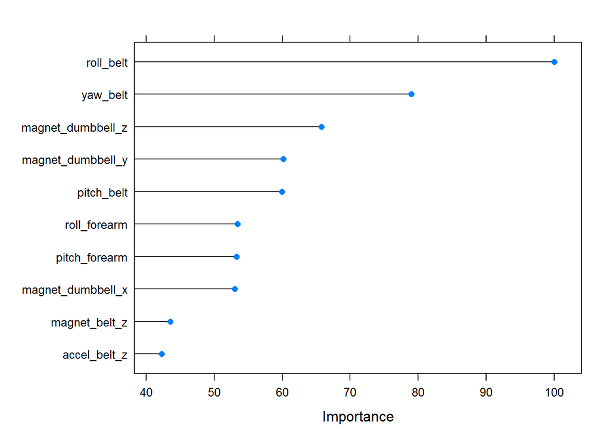

```r
viRF <- varImp(modelFitRF)
plot(viRF, top = 10)
```

## Predict Test Set Error Class

The following are the predicted error classes for each of the 20 observations in the test dataset.

```r
predict(modelFitRF, pml_tst)
```

```
##  [1] B A B A A E D B A A B C B A E E A B B B
## Levels: A B C D E
```

## References

Velloso, E.; Bulling, A.; Gellersen, H.; Ugulino, W.; Fuks, H. Qualitative Activity Recognition of Weight Lifting Exercises. Proceedings of 4th International Conference in Cooperation with SIGCHI (Augmented Human ’13) . Stuttgart, Germany: ACM SIGCHI, 2013.